# Linear Programming for Route Planning and Job Scheduling

Timothy Wong[^1]

2024-05-21

# Abstract

Efficiently managing travel and job scheduling for multiple travelling agents across various locations presents a significant operational challenge. We use a Linear Programming (LP) model designed to optimise route planning and job allocation among agents, aiming to minimise travel time and adhere to individual working hours constraints. Utilising variables such as travel costs, job durations, and resource capacities, we construct a mathematical framework that accommodates each agent’s starting location and contractual obligations. Experimental results, visualised through Gantt charts and geographical plotting, demonstrate the model’s efficacy in reducing total travel time while ensuring equitable workload distribution. This approach not only enhances operational efficiency but also contributes to the broader field of operations research by providing a scalable solution for multi-location, multi-personnel scheduling problems.

This tutorial is modified from the well-known Multiple Traveling Salesman Problem (m-TSP).

```r
library(knitr)
library(dplyr)
library(tidyr)
library(ompr)
library(ompr.roi)
library(ROI)
library(ROI.plugin.glpk)
library(ROI.plugin.symphony)
library(igraph)
library(ggplot2)
library(ggrepel)
```

# Problem Overview

The following variables are used in the Linear Programming problem:

$$\begin{aligned}
& \text{Let} & I & = \text{No. of locations} \\
& & K & = \text{No. of travelling agents} \\
& & x & = \text{Allocation matrix} \\
& & v & = \text{Travel costs matrix} \\
& & d & = \text{Job costs vector} \\
& & f & = \text{Offsets vector} \\
& & c & = \text{Capacities vector} \\
& & p & = \text{Depots vector} \\
\end{aligned}$$

```r
set.seed(12345)

# Number of locations
I <- 14

# Number of travelling agents
K <- 3

# Hours offset for each agent
offsets <- sample(c(7:10), K, replace = TRUE)

# Capacity for each agent
capacities <- sample(c(8:12), K, replace = TRUE)

# Generate random locations (x-y coordinates) and job costs
# Job costs are randomly generated form a Poisson distribution.
locations <- tibble(id = 1:I,
                    x=runif(I),
                    y=runif(I),
                    cost = rpois(I,1)+1)

# Calculate travel costs between locations (Euclidean distance is used here)
travel_costs <- as.matrix(dist(select(locations, x, y),
                               diag = TRUE, upper = TRUE))

# Depots are randomly selected
depots <- sample(locations$id, K)

# Depots have the hours offset as cost
locations[depots,]$cost <- offsets

# Add a Boolean flag 'is_depot'
locations <- locations %>% mutate(is_depot = id %in% depots)

# Show table
locations
```

```
## # A tibble: 14 × 5
##       id       x       y  cost is_depot
##    <int>   <dbl>   <dbl> <dbl> <lgl>
##  1     1 0.509   0.327       1 FALSE
##  2     2 0.728   0.965       3 FALSE
##  3     3 0.990   0.707       3 FALSE
##  4     4 0.0345  0.645       8 TRUE
##  5     5 0.152   0.390       1 FALSE
##  6     6 0.736   0.699       3 FALSE
##  7     7 0.00114 0.544       2 FALSE
##  8     8 0.391   0.226       9 TRUE
##  9     9 0.462   0.485       3 FALSE
## 10    10 0.388   0.793       1 FALSE
## 11    11 0.402   0.00599    10 TRUE
## 12    12 0.179   0.188       1 FALSE
## 13    13 0.952   0.682       1 FALSE
## 14    14 0.454   0.370       1 FALSE
```

Show the randomly selected depots:

```r
depots
```

```
## [1]  4  8 11
```

The problem can be easily summarised in the following plot. It shows the start locations (depots) of each agent, as well as a set of jobs which have to be completed in the day. The objective is to identify the total shortest routes for all agents, making sure that they begin the journey at start location and return there once the day is done.

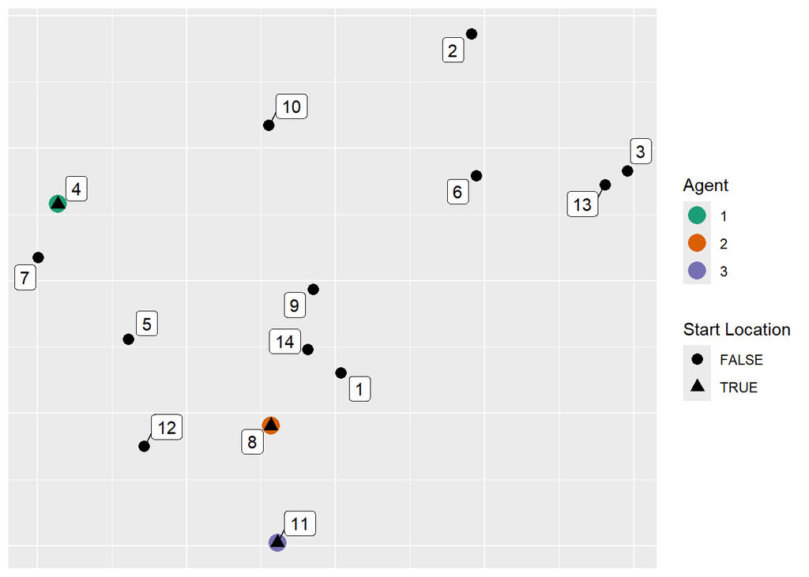

```r
ggplot(locations, aes(x,y)) +
  geom_point(mapping = aes(x,y, colour=as.factor(k)),
             size=5,
             data = tibble(k = 1:K, depot = depots) %>%
               inner_join(locations, by=c("depot"="id"))) +
  geom_point(aes(shape=is_depot), size=3)+
  geom_label_repel(aes(label=id)) +
  labs(shape= "Start Location",
       colour = "Agent",
       x=NULL, y=NULL)  +
  guides(x = "none", y = "none") +
  scale_colour_brewer(type = "qual", palette = 2)
```

# Linear Programming

The Linear Programming problem is formulated as below. It is modified from the Multiple Travelling Salesman Problem (MTSP) example [here](https://dirkschumacher.github.io/ompr/articles/problem-mtsp.html).

$$\begin{aligned}
& \text{Min.} & z & = \sum_{i=1}^{I} \sum_{i^\prime=1}^{I}
\sum_{k=1}^{K} v_{ii^\prime}x_{ii^\prime k} + d_{i^\prime}x_{ii^\prime
k} &\\
& \text{s.t.} &&&&& &\\
& (1) & x_{ii^\prime k} & \in \{{0,1\}} & \forall
& i &=1,2,3,...,I &\\
&&&&& i^\prime &=1,2,3,...,I &\\
&&&&& k^\prime &=1,2,3,...,K &\\
& (2) & \sum_{i=1}^{I} \sum_{i^\prime=1}^{I}
v_{ii^\prime}x_{ii^\prime k} + d_{i^\prime}x_{ii^\prime k} & \leq
f_k + c_k
& \forall &k &=1,2,3,...,K
&\\
& (3) & x_{iik} & = 0 & \forall &i
&=1,2,3,...,I &\\
&&&&& k &=1,2,3,...,K &\\
& (4) & \sum_{i^\prime=1}^{I} x_{p_k i^\prime k } & = 1
& \forall &k &= 1,2,3,...,K &\\
& (5) & \sum_{i=1}^{I} x_{ip_k k} & = 1 & \forall
&k &= 1,2,3,...,K &\\
& (6) & \sum_{i^\prime=1}^{I} x_{i^\prime ik} & =
\sum_{i^\prime=1}^{I}x_{ii^\prime k} & \forall &i &=
1,2,3,...,I &\\
&&&&& k &=1,2,3,...,K &\\
& (7) & \sum_{i^\prime=1}^{I} \sum_{k=1}^{K} x_{i i^\prime k}
& = 1 & \forall &i &= 1,2,3,...,I &\\
& (8) & \sum_{i=1}^{I} \sum_{k=1}^{K} x_{i i^\prime k} & =
1 & \forall &i^\prime &= 1,2,3,...,I &\\
& (9) & 1 \leq u_{ik} & \leq I& \forall &k &=
1,2,3,...,K &\\
&&&&& i &= 1,2,3,...,I &\\
&&&&& i &\ne p_k &\\
& (10) & \left.
\begin{array}{ll}
u_{ik} \geq 2 \\
u_{ik} - u_{i^\prime k} +1 \leq (I-1) (1 - x_{i i^\prime k}) \\
\end{array}
\right \} &&&
\forall i &= 1,2,3,...,I \\
&&&&&k &=1,2,3,...,K
&\\
\end{aligned}$$

The LP problem is expressed in `R`using the code chunk below. The experimental function `MILPModel()` is used to speed up computation, it is subject to future [API changes](https://dirkschumacher.github.io/ompr/reference/MILPModel.html).

```r
travel_costs_func <- function(i, i_) {
  vapply(seq_along(i), function(k) travel_costs[i[k], i_[k]], numeric(1L))
}

job_costs_func <- function(i) {
  vapply(seq_along(i), function(k) locations$cost[i[k]], numeric(1L))
}

# the depot is always idx 1
model <- MILPModel() %>%

  # we create a variable that is 1 if we travel from city i to i_ by Salesman k
  add_variable(x[i, i_, k],
               i = 1:I,
               i_ = 1:I,
               k = 1:K, type = "binary") %>%

  # minimize travel costs and latest arrival
  set_objective(sum_expr(colwise(travel_costs_func(i, i_)) * x[i, i_, k] +
                           colwise(job_costs_func(i_)) * x[i, i_, k],
                         i = 1:I,
                         i_ = 1:I,
                         k = 1:K), "min") %>%

  # Total travel and i_ob costs must not exceed agent capacity
  add_constraint(sum_expr(colwise(travel_costs_func(i, i_)) * x[i, i_, k] +
                            colwise(job_costs_func(i_)) * x[i, i_, k],
                          i = 1:I,
                          i_ = 1:I) <= colwise(offsets[k]) + colwise(capacities[k]),
                 k=1:K) %>%

  # you cannot go to the same city
  add_constraint(x[i, i, k] == 0,
                 i = 1:I,
                 k = 1:K) %>%

  # each salesman needs to leave the depot
  add_constraint(sum_expr(x[depots[k], i_, k],
                          i_ = 1:I) == 1,
                 k = 1:K) %>%

  # each salesman needs to come back to the depot
  add_constraint(sum_expr(x[i, depots[k], k],
                          i = 1:I) == 1,
                 k = 1:K) %>%

  # # if a salesman comes to a city he has to leave it as well
  add_constraint(sum_expr(x[i_, i, k], i_ = 1:I) == sum_expr(x[i, i_, k], i_ = 1:I),
                i = 1:I,
                k = 1:K) %>%

  # leave each city with only one salesman
  add_constraint(sum_expr(x[i, i_, k], i_ = 1:I, k = 1:K) == 1, i = 1:I) %>%

  # arrive at each city with only one salesman
  add_constraint(sum_expr(x[i, i_, k], i = 1:I, k = 1:K) == 1, i_ = 1:I) %>%

  # a helper variable for the MTZ formulation of the tsp
  add_variable(u[i, k], i = 1:I, k = 1:K, lb = 1, ub = I)


# Add MTZ constraints for each k worker
# ensure no subtours (arc constraints)
for (k_ in 1:K) {

  my_depot <- depots[k_]

  model <- model %>%
    # # each salesman needs to leave the depot
    # add_constraint(sum_expr(x[my_depot, i_, k_],
    #                         i_ = 1:I) == 1) %>%
    #
    # # each salesman needs to come back to the depot
    # add_constraint(sum_expr(x[i, my_depot, k_],
    #                         i = 1:I) == 1) %>%

    add_constraint(u[i, k] >= 2, i = (1:I)[-my_depot], k = k_) %>%
    add_constraint(u[i, k] - u[i_, k] + 1 <= (I - 1) * (1 - x[i, i_, k]),
                   i = (1:I)[-my_depot], i_ = (1:I)[-my_depot], k = k_)
}
```

Alternatively the `symphony` solver can be used. The `time_limit` parameter is used to control maximum execution time. Optional parameter `gap_limit` can be used for early-stopping.

```r
# system.time({
#   result <- solve_model(model, with_ROI(solver = "glpk"
#                                         #sec = 1,
#                                         #ratio = 0
#                                         #maxN = 1000
#                                         #maxso = 1
#                                         ))
# })

system.time({
  result <- solve_model(model, with_ROI(solver = "symphony",
                                        verbosity = -1,
                                        gap_limit = 5,
                                        time_limit = 60 * 20
                                        ))
})
```

```
##    user  system elapsed
##    2.75    0.05    2.87
```

# Extract solution

Once a solution is found for the LP problem, the solution is extracted. Binary variable `x` is the allocation matrix indicating the travel routes for all agents.

```r
x <- get_solution(result, x[i, i_, k]) %>%
  select(i, i_, k, x=value) %>%
  filter(x == 1) %>%
  select(-x) %>%
  as_tibble()

u <- get_solution(result, u[i, k]) %>%
  select(i,k,u=value) %>%
  inner_join(x, by=c("i", "k")) %>%
  as_tibble()

u$travel_cost <- apply(u, 1, function(r){ travel_costs[as.integer(r["i"]), as.integer(r["i_"])] })
u$job_cost <- locations$cost[locations$id[u$i]]

routes <- u %>%
  inner_join(select(locations, id,x=x,y=y, is_depot), by=c("i"= "id")) %>%
  inner_join(select(locations, id,xend=x,yend=y), by=c("i_"= "id"))
```

# Convert solution into graph

We will convert the route into a more meaningful `scheudle` data frame where the series of tasks can be visualised. Agents will perform job at location $i$ whilst incurring the cost here, then travel to the next location $i^\prime$ and bear the travel cost. The task order is identified using the `id` column. Since the fist job is always the offset block with cost $f_k$, this is taken off from the schedule. An additional `spare` block is appended to the end of day if the agent’s total travel and job time is below the contracted capacity hours.

```r
schedule <- do.call(bind_rows, lapply(1:K, function(k_){
  routes_subset <- u %>%
    filter(k==k_) %>%
    arrange(u)

  # Agent performs job at location i
  jobs <- routes_subset %>%
    transmute(k, task = paste0("Job ", i), cost = job_cost,
              id = row_number() + 0, type="job")

  # Agent will travel from location i to i'
  trips <- routes_subset %>%
    transmute(k, task = paste0(i, "->",i_), cost = travel_cost,
              id = row_number() + 0.1, type="travel")

  route <- union_all(jobs, trips) %>%
    arrange(id, type) %>%
    mutate(id = row_number(),
           end_time = cumsum(cost),
           start_time = lag(end_time, 1, default = 0)) %>%
    filter(!(type =="job" & id == 1)) %>%
    mutate(id = row_number())

  last_job <- max(route$end_time)
  end_time <- (offsets + capacities)[k_]

  if(last_job < end_time) {
    route <- route %>% add_row(tibble(k=k_,
                             task = "spare",
                             cost = end_time - last_job,
                             id= max(route$id)+1,
                             type="spare",
                             start_time = last_job,
                             end_time = end_time))
  }

  route
})) %>%
  mutate(type = factor(type, levels = c("job", "travel", "spare")))

schedule
```

```
## # A tibble: 28 × 7
##        k task    cost    id type   end_time start_time
##    <int> <chr>  <dbl> <dbl> <fct>     <dbl>      <dbl>
##  1     1 4->9   0.457     1 travel     8.46       8
##  2     1 Job 9  3         2 job       11.5        8.46
##  3     1 9->12  0.410     3 travel    11.9       11.5
##  4     1 Job 12 1         4 job       12.9       11.9
##  5     1 12->7  0.398     5 travel    13.3       12.9
##  6     1 Job 7  2         6 job       15.3       13.3
##  7     1 7->4   0.106     7 travel    15.4       15.3
##  8     1 spare  1.63      8 spare     17         15.4
##  9     2 8->6   0.584     1 travel     9.58       9
## 10     2 Job 6  3         2 job       12.6        9.58
## # ℹ 18 more rows
```

Summarise the optimised schedule:

```r
# Summary of each agent
agent_summary <- schedule %>%
  group_by(k) %>%
  summarise(start_time = min(start_time),
            end_time = max(end_time)) %>%
  inner_join(schedule %>%
               group_by(k, type) %>%
               summarise(cost = sum(cost)) %>%
               pivot_wider(names_from = type, values_from = cost),
             by="k")
```

[output not shown]

```r
agent_summary
```

```
## # A tibble: 3 × 6
##       k start_time end_time   job travel spare
##   <int>      <dbl>    <dbl> <dbl>  <dbl> <dbl>
## 1     1          8       17     6   1.37  1.63
## 2     2          9       20     8   1.99  1.01
## 3     3         10       19     6   1.96  1.04
```

# Visualisation

The schedule can be visualised as a Gantt chart. It shows the optimal order of job for all agents

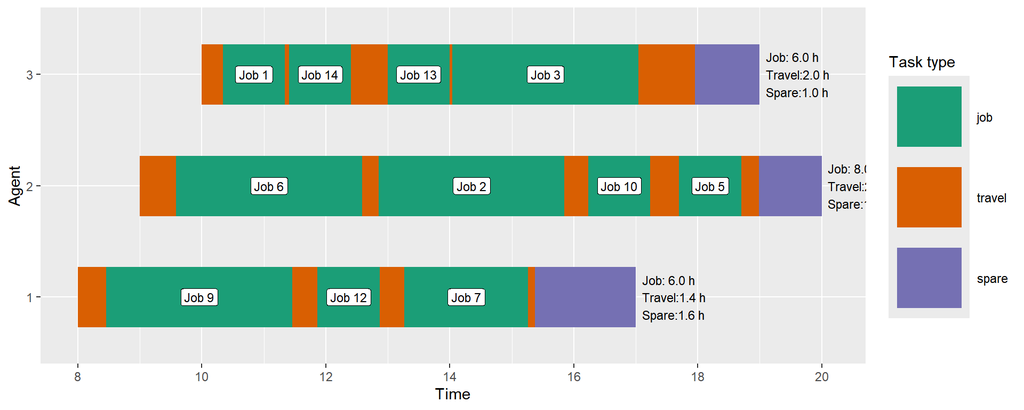

```r
# Create a Gantt chart
ggplot() +
  geom_linerange(data = schedule,
                 mapping = aes(y = as.factor(k),
                     xmin = start_time,
                     xmax = end_time,
                     colour = as.factor(type)), size=20) +
  geom_label(data = filter(schedule, type=="job"),
             mapping = aes(x=(start_time+end_time)/2, y=k,label = task),
             size=3) +
  geom_text(data = agent_summary,
            mapping = aes(x=end_time + 0.1,
                          y = k,
                          label=sprintf("Job: %.1f h\nTravel:%.1f h\nSpare:%.1f h",
                                        job,travel, spare)),size=3,hjust =0) +
  xlim(c(0, 24)) +
  labs(x="Time",
       y="Agent",
       colour="Task type") +
  scale_colour_brewer(type = "qual", palette = 2) +
  scale_x_continuous(breaks = seq(0, 24, by = 2))
```

The travel routes can be plotted on the locations.

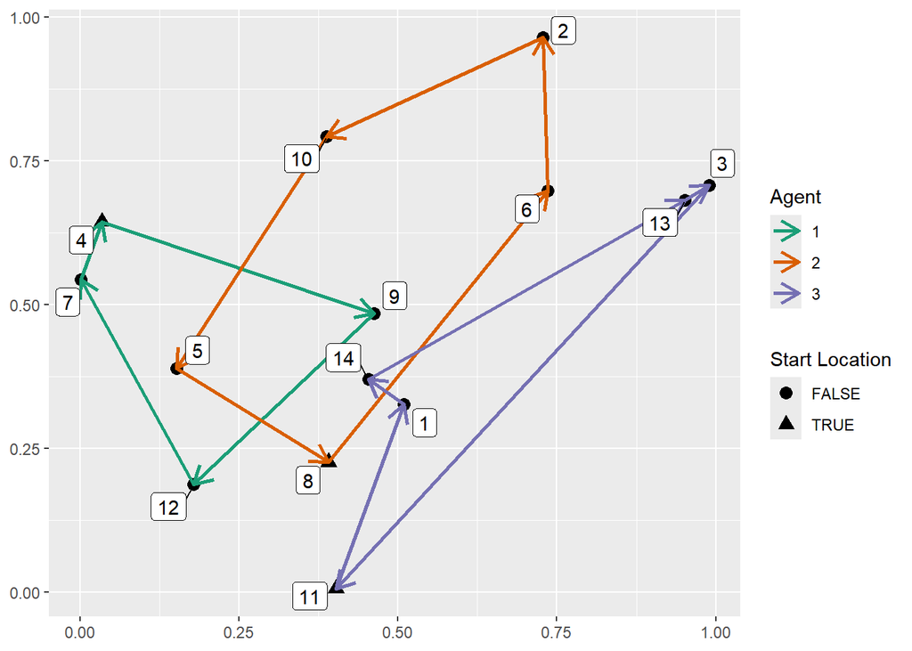

```r
# Plot the routes
ggplot(routes, aes(x, y, xend=xend, yend=yend)) +
  geom_point(aes(shape=is_depot), size=3) +
  geom_curve(mapping = aes(colour=as.factor(k)),
           curvature=0, size=1,
           arrow = arrow(length = unit(0.4, "cm")))+
  geom_label_repel(aes(label=i)) +
  labs(colour = "Agent",
       shape =  "Start Location",
       x = NULL, y = NULL) +
  scale_colour_brewer(type = "qual", palette = 2)
```

[^1]: timothy.wong@hotmail.co.uk